[O’Hara on GitHub](https://github.com/oharac)

# Map trends for all impacted species

Compiled on Fri May 22 20:05:55 2020 by ohara

```r
library(raster)
source('https://raw.githubusercontent.com/oharac/src/master/R/common.R')

source(here('common_fxns.R'))

reload <- FALSE
```

# 1 Summary

Create a species richness map for threatened marine species.

Combine taxa-level trend maps to create maps of number of threatened species overlapping intensifying or deintensifying stressors, per cell.

This is all done at the level of cumulative impact category, not individual stressors.

# 2 Methods

## 2.1 Create species richness map for this assessment

Set up the dataframe of species to include. By taxon, load all species range maps, smash down to taxon-level species richness; then combine these for a total species richness.

See the impact map script for comparisons of summed priority to summed species count…

## 2.2 Setup for mapping across all taxa

For each impact category, sum increasing and decreasing stressor locations for both count and priority:

- gather all taxa-level map files for increasing or decreasing stressors into a raster stack
- collapse the stack using `calc(fun = sum, na.rm = TRUE)`

### 2.2.1 Calculate intensification trends by count

Pull the taxon-level maps for each impact category, for both intensifying and de-intensifying impacts.

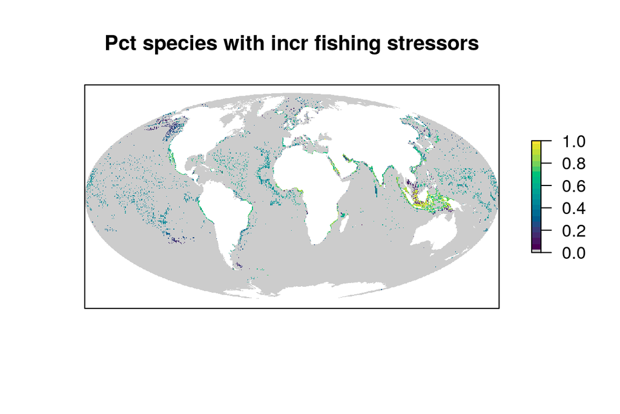

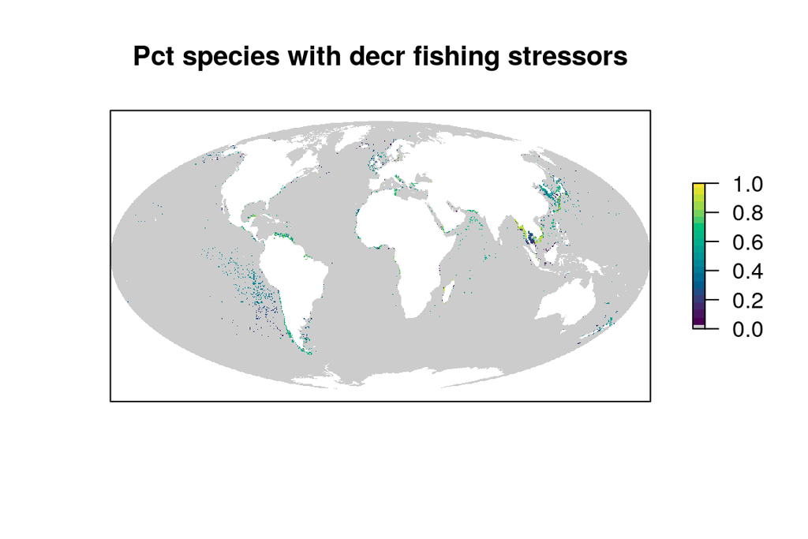

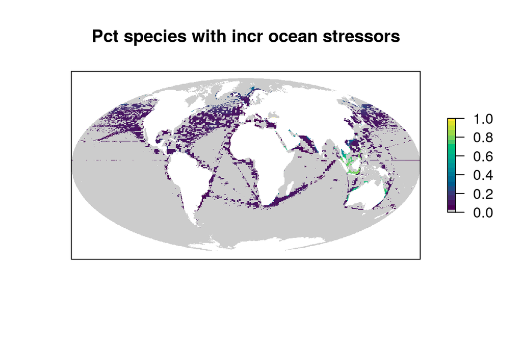

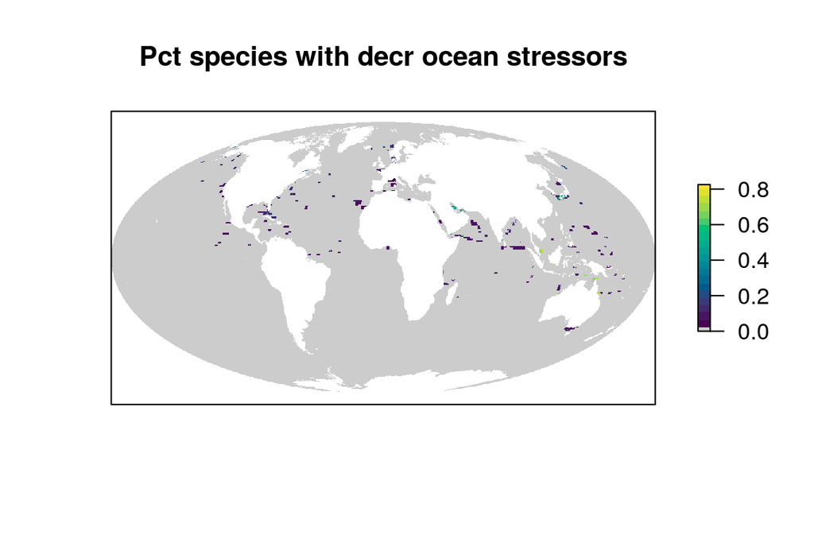

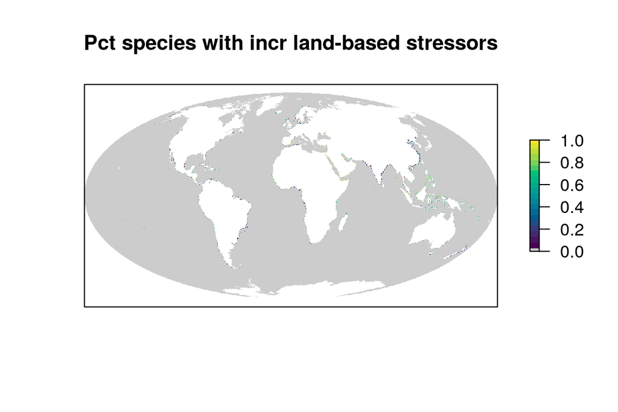

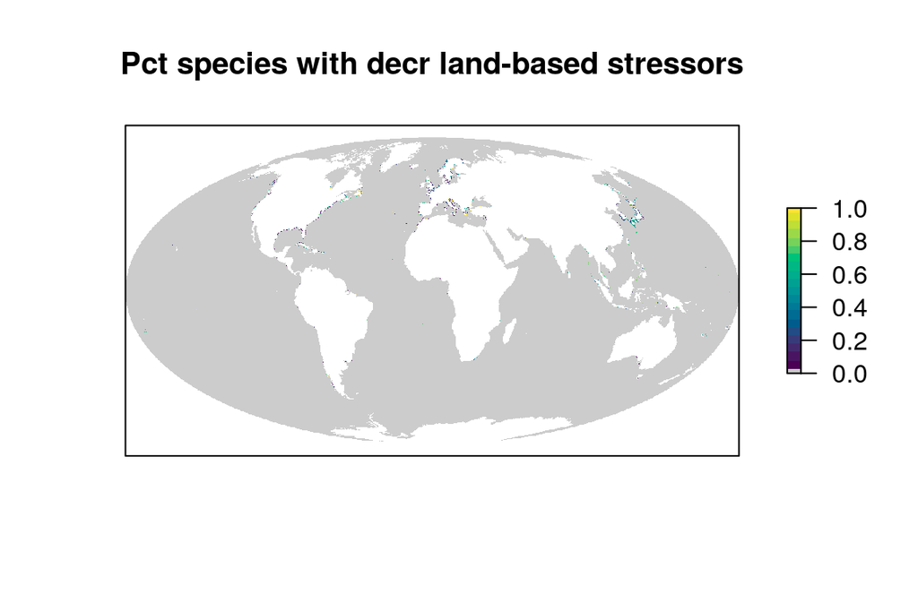

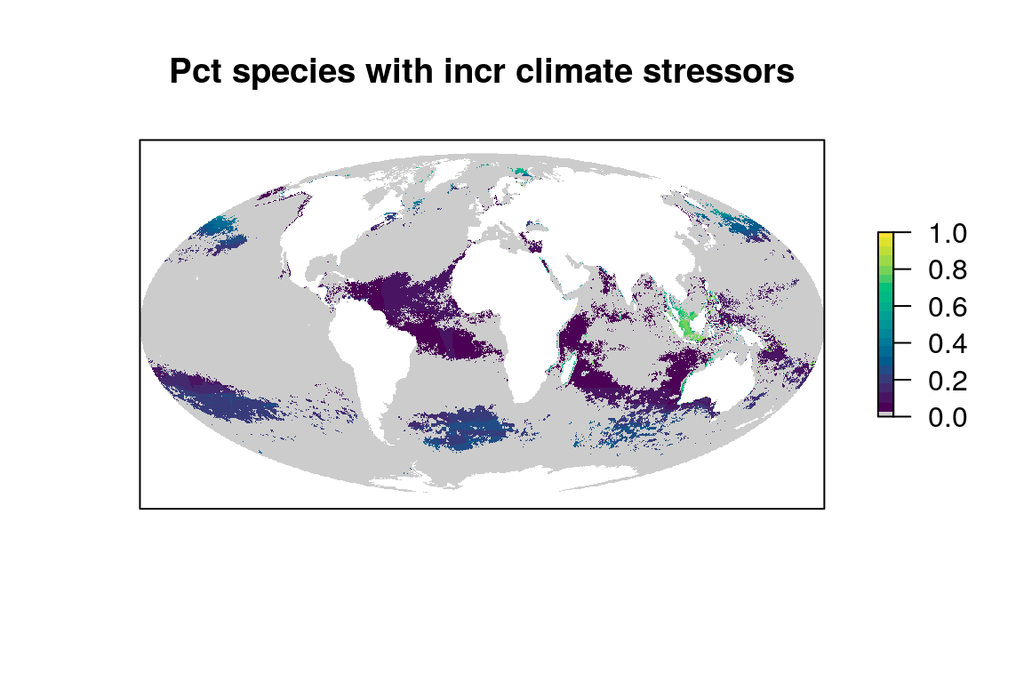

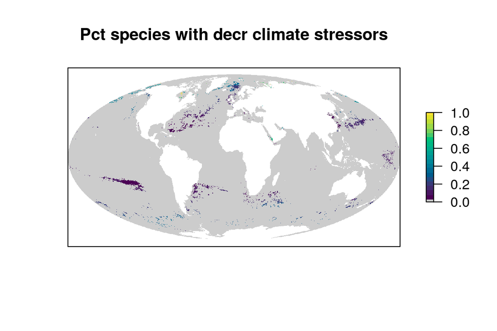

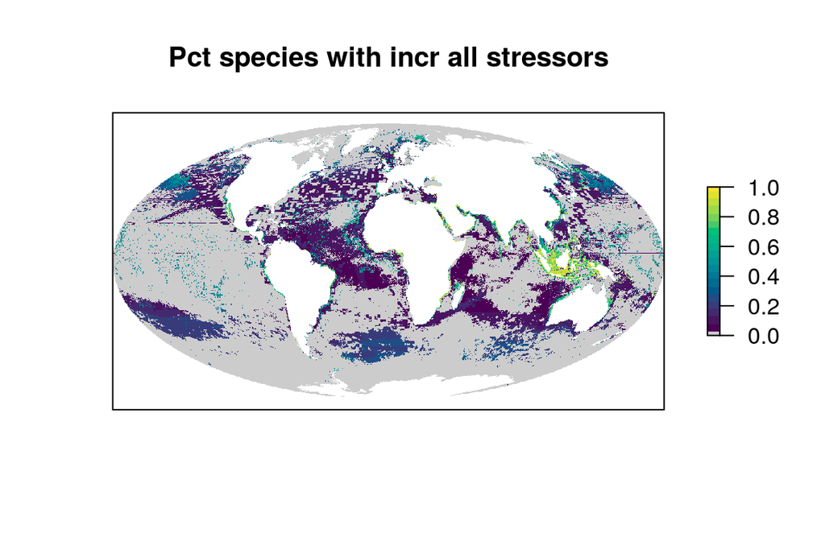

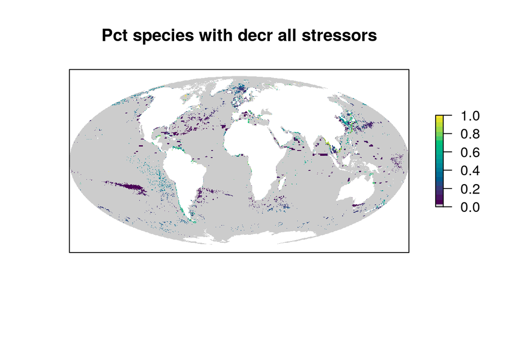

### 2.2.2 Calculate intensification trends by priority-weighted count

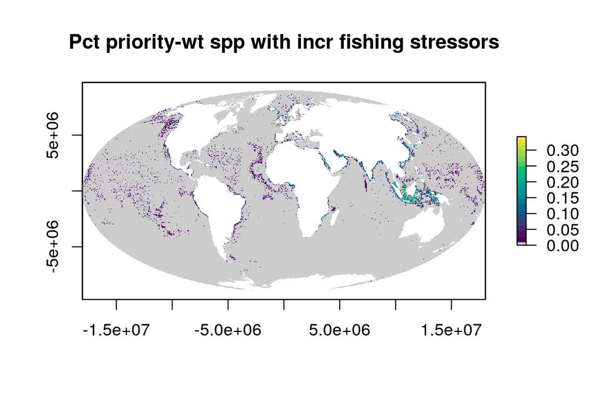

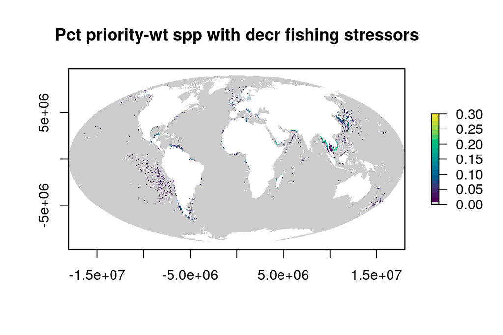

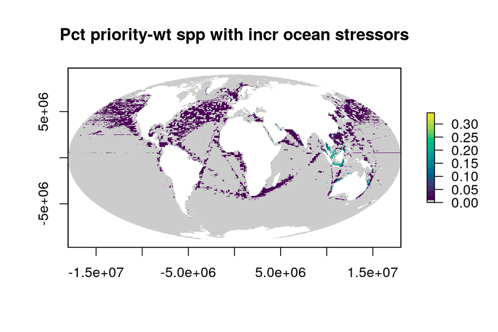

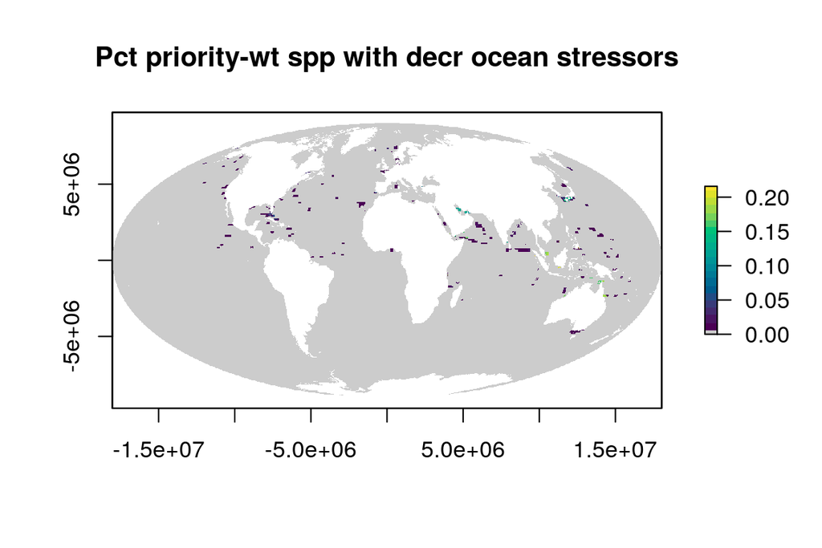

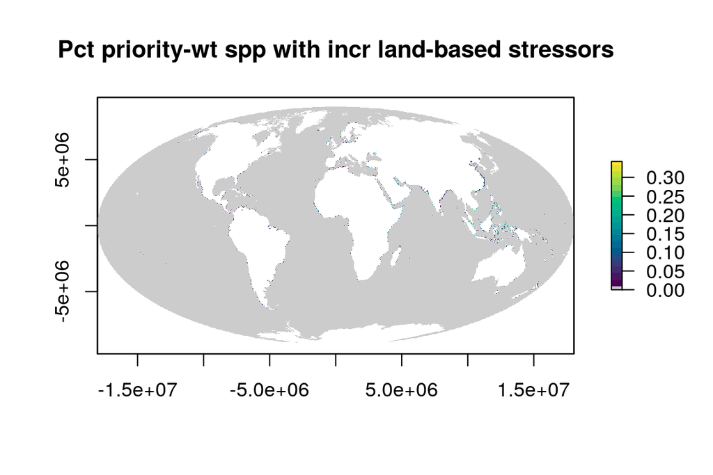

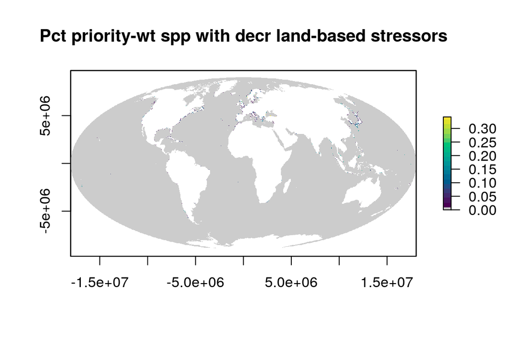

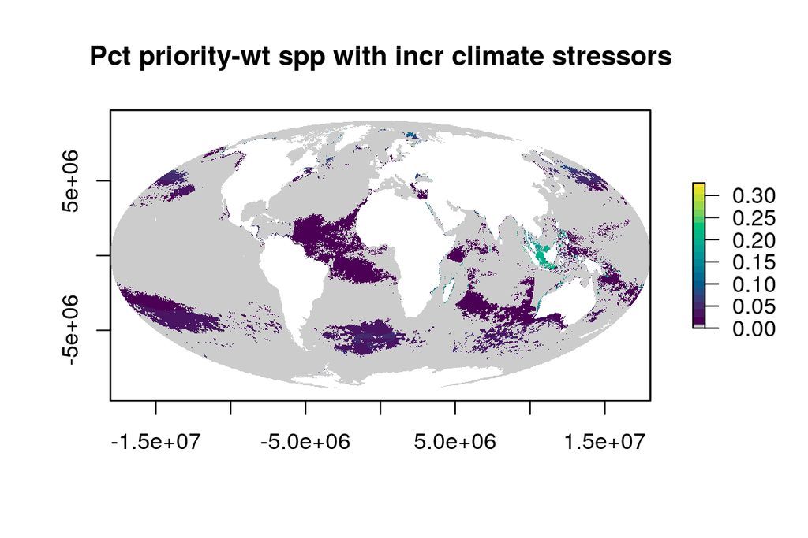

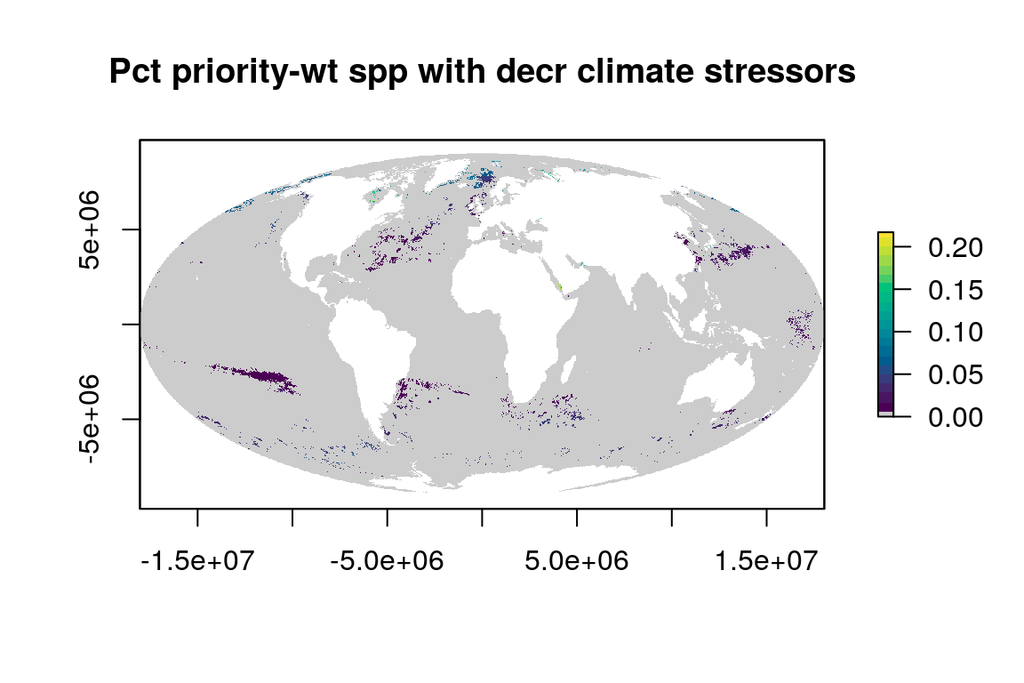

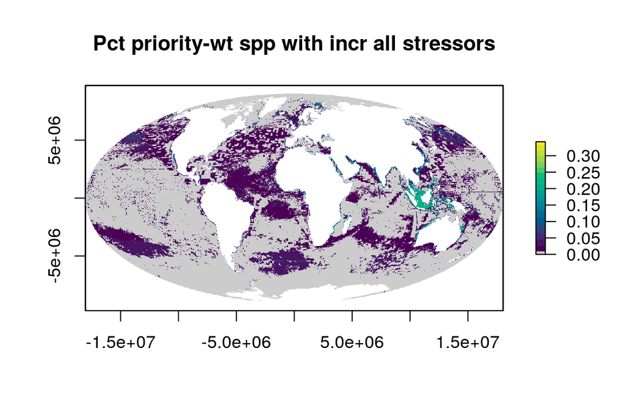

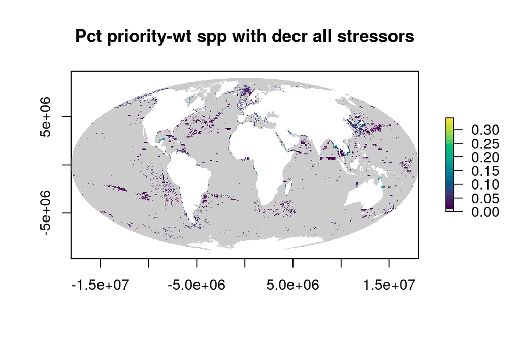